# PCA & 앙상블 Stacking : kaggle-House Prices

newhyh

2021-08-22

### 캐글 대회 집값 데이터 - PCA & stacking ensemble

https://www.kaggle.com/c/house-prices-advanced-regression-techniques/data

#### [ 분석 개요 ]

##### ‘방 수’,‘차고 수’,‘수영장 유무’,‘판매연도’, 등으로 구성된 80개의 독립변수가 있으며, 결과변수인 집값(sale_price)을 예측하는 것이 목표이다.

##### 분석의 어려운 점은 독립 변수가 80개인 것이며, 차원축소가 필요해 보인다.

##### 원 데이터(train.csv)로 진행하여 캐글에 제출한 결과 스코어는 0.12712이다.

##### 80개의 독립변수들을 세부적으로 분석하여 전처리를 한다면 스코어가 더 좋아질 수 있을 것으로 예상된다.

##### 본 분석에서는 주어진 학습 데이터(train.csv)를 다시 train과 test로 분리하여 성능평가까지 진행함.

library(knitr)

[figure not shown]

#### [ 분석 핵심 KEY ]

##### **PCA 차원축소 : 80여개의 데이터를 모두 선별하기 어려우므로 주성분 분석으로 차원축소를 시행**

##### **stacking 앙상블을 적용하며, 과적합 방지를 위해 앙상블에 패널티회귀를 포함**

```r
library(tidyverse)
library(recipes)
library(rsample)
library(caret)
library(glmnet)
library(caretEnsemble)
library(car)
library(corrplot)
library(tictoc)
library(doParallel)
```

**데이터 불러오기**

```r
file_path <- "./data/"
files <- list.files(file_path)
all_data0 <- read_csv(file.path(file_path, "train.csv"))
all_data <- all_data0 %>% janitor::clean_names()
```

#### **EDA**

```r
all_data %>% as.data.frame() %>% str()
```

**명목형/수치형 변수 개수**

```r
all_data %>% select_if(is.character) %>% ncol()
```

```
## [1] 43
```

```r
all_data %>% select_if(is.numeric )%>% ncol()
```

```
## [1] 38
```

**결측치 확인**

```r
all_data %>% is.na() %>% colSums()
```

[output not shown]

**반응변수 히스토그램**

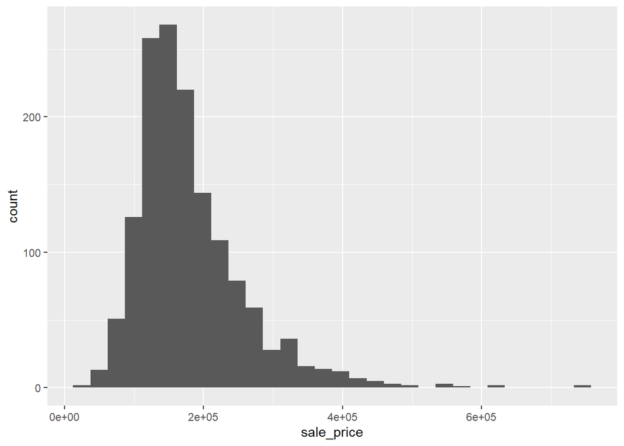

```r
all_data %>%
  ggplot(aes(x = sale_price)) +
  geom_histogram()
```

오른쪽 꼬리 분포이다. 박스콕스 변환 고려

#### **독립변수**

**수치형 변수**

```r
data_num <- all_data %>% select_if(is.numeric) %>% select(-id)
data_num %>% summary()
```

```
##   ms_sub_class    lot_frontage       lot_area       overall_qual
##  Min.   : 20.0   Min.   : 21.00   Min.   :  1300   Min.   : 1.000
##  1st Qu.: 20.0   1st Qu.: 59.00   1st Qu.:  7554   1st Qu.: 5.000
##  Median : 50.0   Median : 69.00   Median :  9478   Median : 6.000
##  Mean   : 56.9   Mean   : 70.05   Mean   : 10517   Mean   : 6.099
##  3rd Qu.: 70.0   3rd Qu.: 80.00   3rd Qu.: 11602   3rd Qu.: 7.000
##  Max.   :190.0   Max.   :313.00   Max.   :215245   Max.   :10.000
##                  NA's   :259
##   overall_cond     year_built   year_remod_add  mas_vnr_area
##  Min.   :1.000   Min.   :1872   Min.   :1950   Min.   :   0.0
##  1st Qu.:5.000   1st Qu.:1954   1st Qu.:1967   1st Qu.:   0.0
##  Median :5.000   Median :1973   Median :1994   Median :   0.0
##  Mean   :5.575   Mean   :1971   Mean   :1985   Mean   : 103.7
##  3rd Qu.:6.000   3rd Qu.:2000   3rd Qu.:2004   3rd Qu.: 166.0
##  Max.   :9.000   Max.   :2010   Max.   :2010   Max.   :1600.0
##                                                NA's   :8
##   bsmt_fin_sf1     bsmt_fin_sf2      bsmt_unf_sf     total_bsmt_sf
##  Min.   :   0.0   Min.   :   0.00   Min.   :   0.0   Min.   :   0.0
##  1st Qu.:   0.0   1st Qu.:   0.00   1st Qu.: 223.0   1st Qu.: 795.8
##  Median : 383.5   Median :   0.00   Median : 477.5   Median : 991.5
##  Mean   : 443.6   Mean   :  46.55   Mean   : 567.2   Mean   :1057.4
##  3rd Qu.: 712.2   3rd Qu.:   0.00   3rd Qu.: 808.0   3rd Qu.:1298.2
##  Max.   :5644.0   Max.   :1474.00   Max.   :2336.0   Max.   :6110.0
##
##   x1st_flr_sf    x2nd_flr_sf   low_qual_fin_sf    gr_liv_area
##  Min.   : 334   Min.   :   0   Min.   :  0.000   Min.   : 334
##  1st Qu.: 882   1st Qu.:   0   1st Qu.:  0.000   1st Qu.:1130
##  Median :1087   Median :   0   Median :  0.000   Median :1464
##  Mean   :1163   Mean   : 347   Mean   :  5.845   Mean   :1515
##  3rd Qu.:1391   3rd Qu.: 728   3rd Qu.:  0.000   3rd Qu.:1777
##  Max.   :4692   Max.   :2065   Max.   :572.000   Max.   :5642
##
##  bsmt_full_bath   bsmt_half_bath      full_bath       half_bath
##  Min.   :0.0000   Min.   :0.00000   Min.   :0.000   Min.   :0.0000
##  1st Qu.:0.0000   1st Qu.:0.00000   1st Qu.:1.000   1st Qu.:0.0000
##  Median :0.0000   Median :0.00000   Median :2.000   Median :0.0000
##  Mean   :0.4253   Mean   :0.05753   Mean   :1.565   Mean   :0.3829
##  3rd Qu.:1.0000   3rd Qu.:0.00000   3rd Qu.:2.000   3rd Qu.:1.0000
##  Max.   :3.0000   Max.   :2.00000   Max.   :3.000   Max.   :2.0000
##
```

[output cut: 25 more lines]

```
##  Min.   :  0.000   Min.   :    0.00   Min.   : 1.000   Min.   :2006
##  1st Qu.:  0.000   1st Qu.:    0.00   1st Qu.: 5.000   1st Qu.:2007
##  Median :  0.000   Median :    0.00   Median : 6.000   Median :2008
##  Mean   :  2.759   Mean   :   43.49   Mean   : 6.322   Mean   :2008
##  3rd Qu.:  0.000   3rd Qu.:    0.00   3rd Qu.: 8.000   3rd Qu.:2009
##  Max.   :738.000   Max.   :15500.00   Max.   :12.000   Max.   :2010
##
##    sale_price
##  Min.   : 34900
##  1st Qu.:129975
##  Median :163000
##  Mean   :180921
##  3rd Qu.:214000
##  Max.   :755000
##
```

```r
# data_num %>% ncol() 37
```

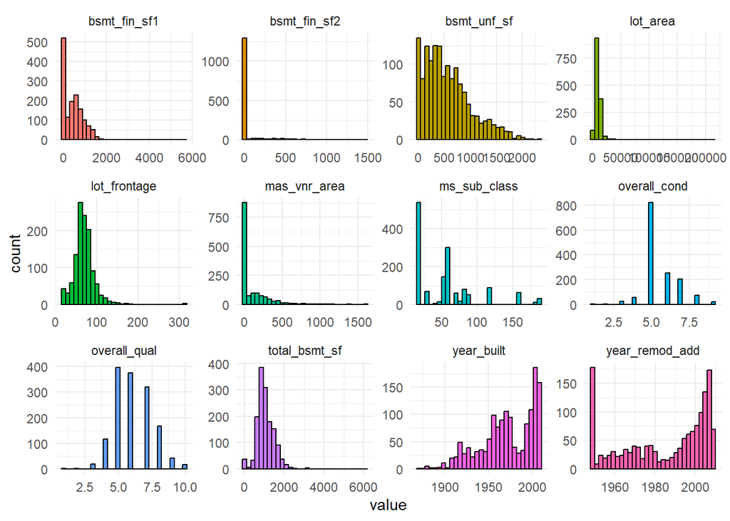

```r
data_num[,1:12] %>% gather() %>%
  ggplot() +
  geom_histogram(mapping = aes(x=value,fill=key), color="black") +
  facet_wrap(~ key, scales = "free") +
  theme_minimal() +
  theme(legend.position = 'none')
```

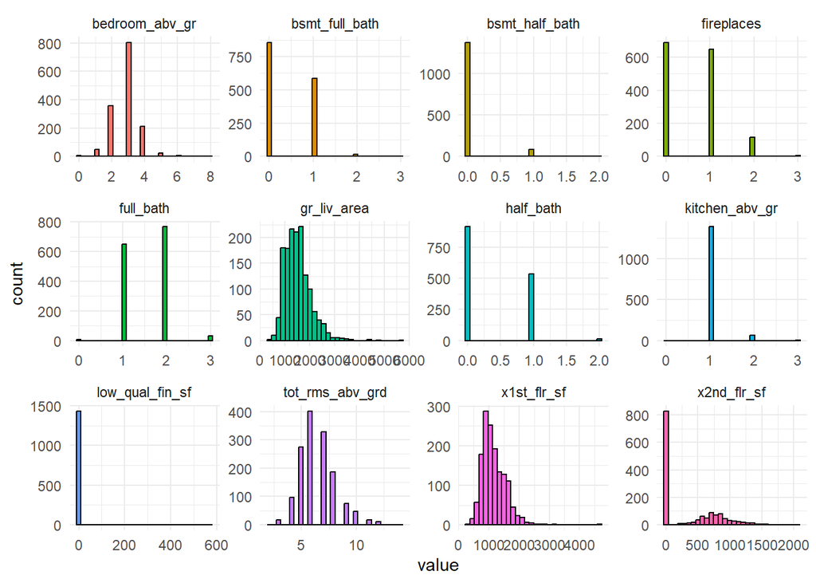

```r
data_num[,13:24] %>% gather() %>%
  ggplot() +
  geom_histogram(mapping = aes(x=value,fill=key), color="black") +
  facet_wrap(~ key, scales = "free") +
  theme_minimal() +
  theme(legend.position = 'none')
```

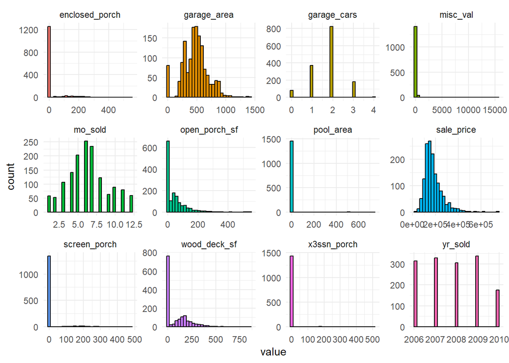

```r
data_num[,26:37] %>% gather() %>%
  ggplot() +
  geom_histogram(mapping = aes(x=value,fill=key), color="black") +
  facet_wrap(~ key, scales = "free") +
  theme_minimal() +
  theme(legend.position = 'none')
```

상관계수 확인

**상관계수 확인**

```r
data_num %>% na.omit() %>% cor()
#corrplot(cm,method="number", order="AOE" )
```

[output not shown]

#### **전처리**

```r
# 박스콕스 변환 필요성 여부
summary(powerTransform(all_data$sale_price))
```

```
## bcPower Transformation to Normality
##                     Est Power Rounded Pwr Wald Lwr Bnd Wald Upr Bnd
## all_data$sale_price   -0.0769           0      -0.1681       0.0142
##
## Likelihood ratio test that transformation parameter is equal to 0
##  (log transformation)
##                            LRT df     pval
## LR test, lambda = (0) 2.723665  1 0.098871
##
## Likelihood ratio test that no transformation is needed
##                            LRT df       pval
## LR test, lambda = (1) 517.8114  1 < 2.22e-16
```

```r
# 2.22e-16 < 0.05이므로 변환 필요함
```

**반응변수 박스콕스 변환**

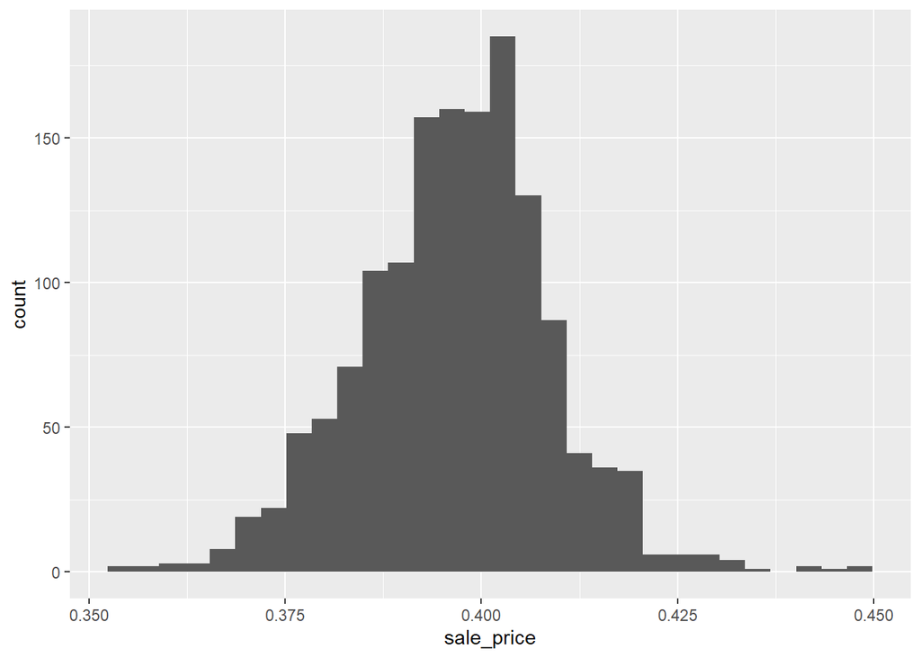

```r
p <- powerTransform(all_data$sale_price)
all_data$sale_price <- all_data$sale_price^p$lambda
all_data %>%
  ggplot(aes(x = sale_price)) +
  geom_histogram()
```

문자형 범주형 변환

```r
all_data_1 <- all_data %>% mutate_if(is.character,factor)
```

**데이터 분할**

```r
splits <- initial_split(all_data_1, prop = 0.7, strata = sale_price)
train0 <- training(splits)
test0 <- testing(splits)
```

#### **주성분 분석 : 레시피에서 처리**

**threshold = 0.80 : 주성분 80%까지 설정**

```r
rec1 <- train0 %>%
  recipe(sale_price ~ .) %>%
  step_impute_knn(all_predictors()) %>%
  step_zv(all_numeric_predictors()) %>%
  step_nzv(all_numeric_predictors())%>%
  step_corr(all_numeric_predictors(), threshold = .9) %>%
  #step_dummy(all_nominal_predictors()) %>%
  step_normalize(all_numeric_predictors()) %>%
  step_pca(all_numeric_predictors(), threshold = 0.80)
```

```r
train_b <- rec1 %>% prep() %>% juice()
test_b <- rec1 %>% prep() %>% bake(new_data = test0)
```

#### **stacking ensemble**

```r
control <- trainControl( method='cv', number=5)
lambda <- 10^seq(-5,5, length=100)
```

```r
file_path <- "./rdata/"
#save.image(file=paste0(file_path, "house_price_upload.RData" ))
load(paste0(file_path, "house_price_upload.RData" ))
```

```r
# essb_model3 <- caretList(sale_price~., data = train_b,
#                         trControl = control,
#                         methodList = c('rf','glmnet', 'glmnet','xgbTree'),
#                         tuneList = list(rft=caretModelSpec(method="rf",tuneLength = 10),
#                                         lasso=caretModelSpec(method="glmnet",tuneGrid=expand.grid(alpha=1, lambda=lambda)),
#                                         ligi =caretModelSpec(method="glmnet",tuneGrid=expand.grid(alpha=0, lambda=lambda)),
#                                        xgbt=caretModelSpec(method="xgbTree",tuneLength = 10)
#                        ))
```

```r
# Stack : glm ==================================================================
glm_ensemble3 <- caretStack(
  essb_model3,
  method="glm",
  metric="RMSE",
  trControl=control
)
# Stack : rf ===================================================================
rf_ensemble3 <- caretStack(
  essb_model3,
  method="rf",
  metric="RMSE",
  trControl=control
)

# Stack : glmnet  ==============================================================
glmnet_ensemble3 <- caretStack(
  essb_model3,
  method="glmnet",
  metric="RMSE",
  trControl=control
)
```

#### **예측 및 성능평가**

```r
ens_glm_preds3 <- predict(glm_ensemble3, newdata=test_b)#, type="prob")
ens_rf_preds3 <- predict(rf_ensemble3, newdata=test_b)#, type="prob")
ens_glmnet_preds3 <- predict(glmnet_ensemble3, newdata=test_b)

postResample(pred =ens_glm_preds3, obs =test_b$sale_price)
```

```
##        RMSE    Rsquared         MAE
## 0.003673445 0.902174010 0.002439220
```

```r
postResample(pred =ens_rf_preds3, obs =test_b$sale_price)
```

```
##        RMSE    Rsquared         MAE
## 0.003620575 0.905051068 0.002532348
```

```r
postResample(pred =ens_glmnet_preds3, obs =test_b$sale_price)
```

```
##        RMSE    Rsquared         MAE
## 0.003694295 0.900916748 0.002416810
```

**예측 데이터 역변환(원 데이터 변환)**

```r
ens_glm_preds3^(1/p$lambda) %>% head()
```

```
##        1        2        3        4        5        6
## 174059.9 149912.5 268136.3 133002.9 157509.0 117725.1
```

```r
ens_rf_preds3^(1/p$lambda) %>% head()
```

```
##        1        2        3        4        5        6
## 181518.5 156401.8 263849.3 133493.0 159963.6 124657.3
```

```r
ens_glmnet_preds3^(1/p$lambda) %>% head()
```

```
##        1        2        3        4        5        6
## 175433.8 152411.4 270037.0 133404.3 156902.4 117239.2
```